# 21 reactable

The `reactable` table offers a lot of features and is very easy to use.

We’re going to build a classic way to look at the sales performance :

- Display of sales between 2 similar periods YTD (Year To Date) and LYTD (Last Year To Date).
- **Comparison of YTD vs LYTD sales.**

For this, **we create first a table with the following features** (i.e. variables) :

- **YTD total sum.**
- **LYTD total sum.**
- **YTD vs LYTD comparison, in value and in percentage.**

And then **we will add a *sparkline***, displaying per product the historical sales per month.

The purpose is to provide a quick picture of the sales pattern, *inside the table*. Always convenient to identify a trend, a seasonality, or some outliers.

We will then transform this data frame into a `reactable` to get a nice display of the results.

> **About the YTD vs LYTD concept** :
> - we consider 2 consecutive years.
> - we compare a similar period of time during those 2 years.

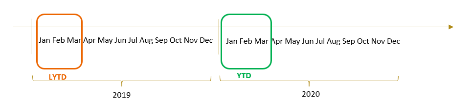

Figure 53 : YTD vs LYTD

As usual, let’s start by uploading the libraries we will use : `tidyverse` for the ETL, `sparkline` to create sparklines (of course!), the 2 libraries `reactable` and `reactablefmtr` for the tables, and also the library `htmltools`.

```r
# ETL
library(tidyverse)
library(sparkline)

# Tables
library(reactable)
library(reactablefmtr)

# Others
library(htmltools) # to render some special html
```

# 22 Get and Tidy demo data frame

We’ll practice using a simple demo data frame :

Let’s upload and tidy our data frame to practice. After the ETL, we will get 6 variables :

- **5 dimensions** :
  - **1 sku_description** : the different types of honey.
  - **4 attributes of time** : period, calendar_year, calendar_month, calendar_month_abb.
- **1 measure** : sales_qty.

```r
# Upload data frame

# Define the URL of the raw CSV file
url <- "https://raw.githubusercontent.com/nguyennico/table_practice/main/Sales_data.csv"

# Read the CSV file from the URL
df1 <- read.csv(url)


# pivot
df1 <- df1 |> gather(key = "period",
                     value = "sales_qty",
                     2:length(df1))

# remove the "X" in front of the period
df1$period <- gsub("X", "",df1$period)

# Format Date
df1$period <- as.Date(df1$period, format = '%m.%d.%Y')

# add the Calendar Year
df1$calendar_year <- year(df1$period)

# add the Calendar.Month
df1$calendar_month <- month(df1$period)


# Add calendar_month_abb
df1$calendar_month_abb <- month.abb[df1$calendar_month]


# create a factor
df1$calendar_month_abb <- factor(df1$calendar_month_abb,
                                 levels = c("Jan","Feb","Mar","Apr","May","Jun",
                                            "Jul","Aug","Sep", "Oct", "Nov", "Dec"))


# Get Results
Set_Up_Sales_data <- df1


glimpse(df1)
```

```
Rows: 648
Columns: 6
$ sku_description    <chr> "Manuka_250gr", "Manuka_500gr", "Manuka_1000gr", "F…
$ period             <date> 2016-10-01, 2016-10-01, 2016-10-01, 2016-10-01, 20…
$ sales_qty          <int> 0, 0, 387, 78, 317, 126, 179, 95, 1325, 184, 124, 1…
$ calendar_year      <dbl> 2016, 2016, 2016, 2016, 2016, 2016, 2016, 2016, 201…
$ calendar_month     <dbl> 10, 10, 10, 10, 10, 10, 10, 10, 10, 10, 10, 10, 10,…
$ calendar_month_abb <fct> Oct, Oct, Oct, Oct, Oct, Oct, Oct, Oct, Oct, Oct, O…
```

# 23 Create YTD vs LYTD

Now let’s create a YTD vs LYTD table.

Note that to create it, we follow the classic methodology we discussed in the previous chapters :

- **1) Get data => 2) Filter => 3) Transform => 4) Visualize : table .**
- it’s a similar approach with the creation of charts.

```r
#----------------------
# Get Data
#----------------------

# set working df
df1 <- Set_Up_Sales_data



#----------------------
# Filter
#----------------------


# filter on Calendar Year
df1 <- df1 |> filter(calendar_year %in% c(2018,2019))


# filter on YTD Calendar Month
df1 <- df1 |> filter(calendar_month <= 9)




#----------------------
# Transform
#----------------------

# Aggregate
df1 <- df1 |> group_by(sku_description, calendar_year) |>
    summarize(sales_qty = sum(sales_qty)
              )
```

```
`summarise()` has regrouped the output.
ℹ Summaries were computed grouped by sku_description and calendar_year.
ℹ Output is grouped by sku_description.
ℹ Use `summarise(.groups = "drop_last")` to silence this message.
ℹ Use `summarise(.by = c(sku_description, calendar_year))` for per-operation
  grouping (`?dplyr::dplyr_by`) instead.
```

```r
# Spread Value
df1 <- df1 |> spread(calendar_year, sales_qty)

# replace missing values (NA) by zero
df1[is.na(df1)] <- 0

# calculate differences
df1$delta_value <- df1$`2019`-df1$`2018`
df1$delta_value_pc <- df1$delta_value / df1$`2018`

# calculate percentage of YTD Net Sales
df1$YTD_value_pc <- df1$`2019` / sum(df1$`2019`)

# Rename columns
df1 <- df1 |> rename(
      YTD_value= `2019`,
      LYTD_value = `2018`
      )

# replace -inf by zero
df1$delta_value_pc <- if_else(is.infinite(df1$delta_value_pc),
                              0,
                              df1$delta_value_pc)


# replace missing by zero
df1$delta_value_pc <- df1$delta_value_pc |> replace_na(0)


# Get Results
ytd_vs_lytd_data <- df1

# display data frame
ytd_vs_lytd_data
```

```
# A tibble: 18 × 6
# Groups:   sku_description [18]
   sku_description  LYTD_value YTD_value delta_value delta_value_pc YTD_value_pc
   <chr>                 <int>     <int>       <int>          <dbl>        <dbl>
 1 Acacia_1000gr          6211      6070        -141        -0.0227      0.109
 2 Acacia_250gr             95         0         -95        -1           0
 3 Acacia_500gr           2485      2719         234         0.0942      0.0486
 4 Flowers_1000gr        10019      8137       -1882        -0.188       0.146
 5 Flowers_250gr          1708      1042        -666        -0.390       0.0186
 6 Flowers_500gr          2893      3920        1027         0.355       0.0701
 7 Forest_1000gr          2720      2894         174         0.0640      0.0518
 8 Forest_250gr            940       807        -133        -0.141       0.0144
 9 Forest_500gr           3117      2876        -241        -0.0773      0.0514
10 Manuka_1000gr          3460      3029        -431        -0.125       0.0542
11 Manuka_250gr             77       140          63         0.818       0.00250
12 Manuka_500gr            508       907         399         0.785       0.0162
13 Mountains_1000gr      13422     13247        -175        -0.0130      0.237
14 Mountains_250gr         795      1063         268         0.337       0.0190
15 Mountains_500gr         927       946          19         0.0205      0.0169
16 Spring_1000gr          2156      1310        -846        -0.392       0.0234
17 Spring_250gr           1947      2145         198         0.102       0.0384
18 Spring_500gr           4120      4667         547         0.133       0.0835
```

Now, let’s visualize the data frame ytd_vs_lytd_data using the `reactable` library.

# 24 Create Reactable

## 24.1 simple reactable

To transform quickly our data frame into a `reactable`, we can just type `reactable(the name of the dataframe)` :

```r
# set a working df
df1 <- ytd_vs_lytd_data

#----------------------
# Table
#----------------------

reactable(df1)
```

| sku_description | LYTD_value | YTD_value | delta_value | delta_value_pc | YTD_value_pc |
| --- | --- | --- | --- | --- | --- |
| Acacia_1000gr | 6211 | 6070 | -141 | -0.0227016583480921 | 0.10854986677158 |
| Acacia_250gr | 95 | 0 | -95 | -1 | 0 |
| Acacia_500gr | 2485 | 2719 | 234 | 0.0941649899396378 | 0.048623902430301 |
| Flowers_1000gr | 10019 | 8137 | -1882 | -0.187843098113584 | 0.145514047103847 |
| Flowers_250gr | 1708 | 1042 | -666 | -0.389929742388759 | 0.0186340957456321 |
| Flowers_500gr | 2893 | 3920 | 1027 | 0.354994815070861 | 0.0701013966630305 |
| Forest_1000gr | 2720 | 2894 | 174 | 0.0639705882352941 | 0.0517534290670434 |
| Forest_250gr | 940 | 807 | -133 | -0.141489361702128 | 0.0144315885477208 |
| Forest_500gr | 3117 | 2876 | -241 | -0.0773179339108117 | 0.0514315348986928 |
| Manuka_1000gr | 3460 | 3029 | -431 | -0.124566473988439 | 0.0541676353296733 |

[output cut: 8 more lines]

We get a very simple table :

- we can feel the design, light and clear, of a `reactable` `.`
- however the columns are a bit “raw”, not formatted yet.

Then, let’s look at more functionnalities to give a better appearance to our table.

## 24.2 sorting table

The previous table was very simple.

Now, let’s add a few more features :

- a more **compact** table : adding the feature `compact = TRUE` .
- **sorting by descending YTD_value**, mentioning 2 elements :
  - `defaultSortOrder = "desc"` : to indicate the direction (descending or by default ascending).
  - `defaultSorted = c("name of the variable")`: to indicate the variable we use to sort the table.
- **formatting the variable** [sku_description] : giving it a **new name** and defining the **column width**.

To format or work on the different variables we will :

- name them inside the code `columns = list(...)`.
- start with the name of the variable in the data frame, followed by `= colDef()`.
  - then, inside the `colDef()`, we will specify different features, such as : a new name, the desired width of the column or some conditional formatting.

```r
# set a working df
df1 <- ytd_vs_lytd_data

# create reactable
reactable(df1, compact = TRUE,


          defaultSortOrder = "desc",
          defaultSorted = c("YTD_value"),

          columns = list(

            sku_description = colDef(name = "Product",
                                     minWidth = 170)

            ) # close columns list



          ) # close reactable
```

| Product | LYTD_value | YTD_value | delta_value | delta_value_pc | YTD_value_pc |
| --- | --- | --- | --- | --- | --- |
| Acacia_1000gr | 6211 | 6070 | -141 | -0.0227016583480921 | 0.10854986677158 |
| Acacia_250gr | 95 | 0 | -95 | -1 | 0 |
| Acacia_500gr | 2485 | 2719 | 234 | 0.0941649899396378 | 0.048623902430301 |
| Flowers_1000gr | 10019 | 8137 | -1882 | -0.187843098113584 | 0.145514047103847 |
| Flowers_250gr | 1708 | 1042 | -666 | -0.389929742388759 | 0.0186340957456321 |
| Flowers_500gr | 2893 | 3920 | 1027 | 0.354994815070861 | 0.0701013966630305 |
| Forest_1000gr | 2720 | 2894 | 174 | 0.0639705882352941 | 0.0517534290670434 |
| Forest_250gr | 940 | 807 | -133 | -0.141489361702128 | 0.0144315885477208 |
| Forest_500gr | 3117 | 2876 | -241 | -0.0773179339108117 | 0.0514315348986928 |
| Manuka_1000gr | 3460 | 3029 | -431 | -0.124566473988439 | 0.0541676353296733 |

[output cut: 8 more lines]

## 24.3 basic columns formatting

The table looks already a bit nicer. Now, let’s add some **variables formatting** :

- **[YTD_value]** : formatting of thousands unit, and a yellow color, also adding a sum, aggregating the values of all the rows.
- **[LYTD_value]** : formatting of thousands unit.
  - same code with [YTD_value], but without the *style* part.
- **[YTD_value_pc]** : formatting as percentage.

**Note :**

- the parts of code to format each variable end with a comma, except the last part.
- we also add at the end the line `defaultColDef = colDef(footerStyle = list(fontWeight = "bold"))`.
  - this will format the total sum of each column as bold.

```r
# set a working df
df1 <- ytd_vs_lytd_data

# create reactable
reactable(df1, compact = TRUE,


          defaultSortOrder = "desc",
          defaultSorted = c("YTD_value"),

          columns = list(

            sku_description = colDef(
              name = "Product",
              minWidth = 170),



            YTD_value = colDef(
              name = "YTD (units)",
              aggregate = "sum",
              footer = function(values) formatC(sum(values),
                                                format = "f",
                                                big.mark = ",",
                                                digits = 0),
              format = colFormat(separators = TRUE,
                                 digits = 0),
              style = list(background = "yellow",
                           fontWeight = "bold")
              ),


            LYTD_value = colDef(
              name = "LYTD (units)",
              aggregate = "sum",
              footer = function(values) formatC(sum(values),
                                                format = "f",
                                                big.mark = ",",
                                                digits = 0),
              format = colFormat(separators = TRUE,
                                 digits = 0)

              ),


            YTD_value_pc = colDef(
              name = "share of YTD Volume (%)",
              format = colFormat(percent = TRUE, digits = 1)
              )


            ), # close columns list


          defaultColDef = colDef(footerStyle = list(fontWeight = "bold"))

          ) # close reactable
```

| Product | LYTD (units) | YTD (units) | delta_value | delta_value_pc | share of YTD Volume (%) |
| --- | --- | --- | --- | --- | --- |
| Acacia_1000gr | 6211 | 6070 | -141 | -0.0227016583480921 | 0.10854986677158 |
| Acacia_250gr | 95 | 0 | -95 | -1 | 0 |
| Acacia_500gr | 2485 | 2719 | 234 | 0.0941649899396378 | 0.048623902430301 |
| Flowers_1000gr | 10019 | 8137 | -1882 | -0.187843098113584 | 0.145514047103847 |
| Flowers_250gr | 1708 | 1042 | -666 | -0.389929742388759 | 0.0186340957456321 |
| Flowers_500gr | 2893 | 3920 | 1027 | 0.354994815070861 | 0.0701013966630305 |
| Forest_1000gr | 2720 | 2894 | 174 | 0.0639705882352941 | 0.0517534290670434 |
| Forest_250gr | 940 | 807 | -133 | -0.141489361702128 | 0.0144315885477208 |
| Forest_500gr | 3117 | 2876 | -241 | -0.0773179339108117 | 0.0514315348986928 |
| Manuka_1000gr | 3460 | 3029 | -431 | -0.124566473988439 | 0.0541676353296733 |

[output cut: 8 more lines]

We now have formatted 3 additional variables in our `reactable`, and it looks even nicer.

Let’s add more formatting.

## 24.4 conditional formatting

Now, let’s work on the 2 variables [delta_value] and [delta_value_pc]. Some of those values are positive and negative.

We will format them based on those signs. For this, we simply introduce an **if then else** **condition with colors**, to the previous syntax, **creating a function.**

We add the syntax `style = function(value){ details about the function}` inside the `colDef()` part.

**Notes :**

- We will learn about the functions in a dedicated chapter. For the time being we will just create and use one in this example, to show how to format further our table.
- The objective is to show how to format, and to reuse this code when we need it.

```r
# set a working df
df1 <- ytd_vs_lytd_data

# create reactable
reactable(df1, compact = TRUE,


          defaultSortOrder = "desc",
          defaultSorted = c("YTD_value"),

          columns = list(

            sku_description = colDef(
              name = "Product",
              minWidth = 170),



            YTD_value = colDef(
              name = "YTD (units)",
              aggregate = "sum",
              footer = function(values) formatC(sum(values),
                                                format = "f",
                                                big.mark = ",",
                                                digits = 0),
              format = colFormat(separators = TRUE,
                                 digits = 0),
              style = list(background = "yellow",
                           fontWeight = "bold")
              ),


            LYTD_value = colDef(
              name = "LYTD (units)",
              aggregate = "sum",
              footer = function(values) formatC(sum(values),
                                                format = "f",
                                                big.mark = ",",
                                                digits = 0),
              format = colFormat(separators = TRUE,
                                 digits = 0)

              ),


            YTD_value_pc = colDef(
              name = "share of YTD Volume (%)",
              format = colFormat(percent = TRUE, digits = 1)
              ),



            delta_value = colDef(
              name = "YTD vs LYTD (units)",
              aggregate = "sum",
              footer = function(values) formatC(sum(values),
                                                format = "f",
                                                big.mark = ",",
                                                digits = 0),
              format = colFormat(separators = TRUE,
                                 digits = 0),

              style = function(value) {
                if (value > 0) {
                  color <- "#008000"
                  } else if (value < 0) {
                    color <- "#e00000"
                    } else {
                      color <- "#777"
                      }
                list(color = color, fontWeight = "bold")
                }
              ),



            delta_value_pc = colDef(
              name = "YTD vs LYTD volumes (%)",
              format = colFormat(percent = TRUE, digits = 1),

              style = function(value) {
                if (value > 0) {
                  color <- "#008000"
                  } else if (value < 0) {
                    color <- "#e00000"
                    } else {
                      color <- "#777"
                      }
                list(color = color, fontWeight = "bold")
                }
              )




            ), # close columns list

          defaultColDef = colDef(footerStyle = list(fontWeight = "bold"))

          ) # close reactable
```

| Product | LYTD (units) | YTD (units) | YTD vs LYTD (units) | YTD vs LYTD volumes (%) | share of YTD Volume (%) |
| --- | --- | --- | --- | --- | --- |
| Acacia_1000gr | 6211 | 6070 | -141 | -0.0227016583480921 | 0.10854986677158 |
| Acacia_250gr | 95 | 0 | -95 | -1 | 0 |
| Acacia_500gr | 2485 | 2719 | 234 | 0.0941649899396378 | 0.048623902430301 |
| Flowers_1000gr | 10019 | 8137 | -1882 | -0.187843098113584 | 0.145514047103847 |
| Flowers_250gr | 1708 | 1042 | -666 | -0.389929742388759 | 0.0186340957456321 |
| Flowers_500gr | 2893 | 3920 | 1027 | 0.354994815070861 | 0.0701013966630305 |
| Forest_1000gr | 2720 | 2894 | 174 | 0.0639705882352941 | 0.0517534290670434 |
| Forest_250gr | 940 | 807 | -133 | -0.141489361702128 | 0.0144315885477208 |
| Forest_500gr | 3117 | 2876 | -241 | -0.0773179339108117 | 0.0514315348986928 |
| Manuka_1000gr | 3460 | 3029 | -431 | -0.124566473988439 | 0.0541676353296733 |

[output cut: 8 more lines]

The table is now pretty easy to read !

# 25 Additional features

## 25.1 Bar positive & negative values

Let’s **create a function** `bar_chart_pos_neg()`, using the library `htmltools` . This function will generate a **dual bars visual**, with 2 colors (here red and green) to better see the percentage variations.

```r
# Render a bar chart with positive and negative values
bar_chart_pos_neg <- function(label, value, max_value = 1, height = "16px",
                              pos_fill = "#32CD32", neg_fill = "#dc3220") {
  neg_chart <- div(style = list(flex = "1 1 0"))
  pos_chart <- div(style = list(flex = "1 1 0"))
  width <- paste0(abs(value / max_value) * 100, "%")

  if (value < 0) {
    bar <- div(style = list(marginLeft = "8px", background = neg_fill, width = width, height = height))
    chart <- div(style = list(display = "flex", alignItems = "center", justifyContent = "flex-end"), label, bar)
    neg_chart <- tagAppendChild(neg_chart, chart)
  } else {
    bar <- div(style = list(marginRight = "8px", background = pos_fill, width = width, height = height))
    chart <- div(style = list(display = "flex", alignItems = "center"), bar, label)
    pos_chart <- tagAppendChild(pos_chart, chart)
  }

  div(style = list(display = "flex"), neg_chart, pos_chart)
}
```

Now let’s create the `reactable` using this new function `bar_chart_pos_neg()` within the attribute `cell()`, for the variable delta_value_pc.

```r
# set a working df
df1 <- ytd_vs_lytd_data

# create reactable
reactable(df1, compact = TRUE,


          defaultSortOrder = "desc",
          defaultSorted = c("YTD_value"),

          columns = list(

            sku_description = colDef(
              name = "Product",
              minWidth = 170),



            YTD_value = colDef(
              name = "YTD (units)",
              aggregate = "sum",
              footer = function(values) formatC(sum(values),
                                                format = "f",
                                                big.mark = ",",
                                                digits = 0),
              format = colFormat(separators = TRUE,
                                 digits = 0),
              style = list(background = "yellow",
                           fontWeight = "bold")
              ),


            LYTD_value = colDef(
              name = "LYTD (units)",
              aggregate = "sum",
              footer = function(values) formatC(sum(values),
                                                format = "f",
                                                big.mark = ",",
                                                digits = 0),
              format = colFormat(separators = TRUE,
                                 digits = 0)

              ),


            YTD_value_pc = colDef(
              name = "share of YTD Volume (%)",
              format = colFormat(percent = TRUE, digits = 1)
              ),



            delta_value = colDef(
              name = "YTD vs LYTD (units)",
              aggregate = "sum",
              footer = function(values) formatC(sum(values),
                                                format = "f",
                                                big.mark = ",",
                                                digits = 0),
              format = colFormat(separators = TRUE,
                                 digits = 0),

              style = function(value) {
                if (value > 0) {
                  color <- "#008000"
                  } else if (value < 0) {
                    color <- "#e00000"
                    } else {
                      color <- "#777"
                      }
                list(color = color, fontWeight = "bold")
                }
              ),




            #------------------
            # new part

            delta_value_pc = colDef(
              name = "YTD vs LYTD volumes (%)",
              format = colFormat(percent = TRUE, digits = 1),


              cell = function(value) {
                label <- paste0(round(value * 100), "%")
                bar_chart_pos_neg(label, value)
                },
              align = "center",
              minWidth = 400
              )


            #------------------




            ), # close columns list

          defaultColDef = colDef(footerStyle = list(fontWeight = "bold"))

          ) # close reactable
```

| Product | LYTD (units) | YTD (units) | YTD vs LYTD (units) | YTD vs LYTD volumes (%) | share of YTD Volume (%) |
| --- | --- | --- | --- | --- | --- |
| Acacia_1000gr | 6211 | 6070 | -141 | -0.0227016583480921 | 0.10854986677158 |
| Acacia_250gr | 95 | 0 | -95 | -1 | 0 |
| Acacia_500gr | 2485 | 2719 | 234 | 0.0941649899396378 | 0.048623902430301 |
| Flowers_1000gr | 10019 | 8137 | -1882 | -0.187843098113584 | 0.145514047103847 |
| Flowers_250gr | 1708 | 1042 | -666 | -0.389929742388759 | 0.0186340957456321 |
| Flowers_500gr | 2893 | 3920 | 1027 | 0.354994815070861 | 0.0701013966630305 |
| Forest_1000gr | 2720 | 2894 | 174 | 0.0639705882352941 | 0.0517534290670434 |
| Forest_250gr | 940 | 807 | -133 | -0.141489361702128 | 0.0144315885477208 |
| Forest_500gr | 3117 | 2876 | -241 | -0.0773179339108117 | 0.0514315348986928 |
| Manuka_1000gr | 3460 | 3029 | -431 | -0.124566473988439 | 0.0541676353296733 |

[output cut: 8 more lines]

It’s getting nice!

With the colors, the table is becoming very easy to read. Let’s continue adding more features to it.

## 25.2 Add monthly sales Sparklines

Now we’re going to :

- **create a 2nd data frame, with a list of values to generate a sparkline.**
  - In this example, we will look at the whole horizon of time, displaying the monthly sales per product.
- Once the 2nd data frame, called *sparkline_data*, is created, we will add it to the 1st data frame *ytd_vs_lytd_data*, using the function `left_join()`.

Then we will have in the final data frame a new variable called “quantity”, which is a **list (of monthly sales values)**.

### 25.2.1 create monthly sparklines

```r
#----------------------
# Create Sparklines
#----------------------

# set a working df
df1 <- Set_Up_Sales_data

# aggregate
df1 <- df1 |> group_by(sku_description, period) |>
      summarise(quantity = sum(sales_qty)
                )

# create list
df1 <- df1 |> group_by(sku_description) |>
      summarise(quantity = list(quantity))

# keep results
sparkline_data <- df1



#----------------------
# Link dataframes
#----------------------

# merge
df1 <- left_join(ytd_vs_lytd_data, sparkline_data)

glimpse(df1)
```

```
Rows: 18
Columns: 7
Groups: sku_description [18]
$ sku_description <chr> "Acacia_1000gr", "Acacia_250gr", "Acacia_500gr", "Flow…
$ LYTD_value      <int> 6211, 95, 2485, 10019, 1708, 2893, 2720, 940, 3117, 34…
$ YTD_value       <int> 6070, 0, 2719, 8137, 1042, 3920, 2894, 807, 2876, 3029…
$ delta_value     <int> -141, -95, 234, -1882, -666, 1027, 174, -133, -241, -4…
$ delta_value_pc  <dbl> -0.02270166, -1.00000000, 0.09416499, -0.18784310, -0.…
$ YTD_value_pc    <dbl> 0.108549867, 0.000000000, 0.048623902, 0.145514047, 0.…
$ quantity        <list> <765, 927, 1412, 717, 800, 906, 596, 713, 642, 695, 5…
```

### 25.2.2 display reactable

Now let’s add the *sparkline part* to the previous `reactable` :

- within the `cell()` function, we add the syntax : `sparkline(df1$quantity[[index]])` .
- using the function `sparkline()` on the variable quantity, which is a list.

```r
# create reactable
reactable(df1, compact = TRUE,


          defaultSortOrder = "desc",
          defaultSorted = c("YTD_value"),

          columns = list(

            sku_description = colDef(
              name = "Product",
              minWidth = 170),



            YTD_value = colDef(
              name = "YTD (units)",
              aggregate = "sum",
              footer = function(values) formatC(sum(values),
                                                format = "f",
                                                big.mark = ",",
                                                digits = 0),
              format = colFormat(separators = TRUE,
                                 digits = 0),
              style = list(background = "yellow",
                           fontWeight = "bold")
              ),


            LYTD_value = colDef(
              name = "LYTD (units)",
              aggregate = "sum",
              footer = function(values) formatC(sum(values),
                                                format = "f",
                                                big.mark = ",",
                                                digits = 0),
              format = colFormat(separators = TRUE,
                                 digits = 0)

              ),


            YTD_value_pc = colDef(
              name = "share of YTD Volume (%)",
              format = colFormat(percent = TRUE, digits = 1)
              ),



            delta_value = colDef(
              name = "YTD vs LYTD (units)",
              aggregate = "sum",
              footer = function(values) formatC(sum(values),
                                                format = "f",
                                                big.mark = ",",
                                                digits = 0),
              format = colFormat(separators = TRUE,
                                 digits = 0),

              style = function(value) {
                if (value > 0) {
                  color <- "#008000"
                  } else if (value < 0) {
                    color <- "#e00000"
                    } else {
                      color <- "#777"
                      }
                list(color = color, fontWeight = "bold")
                }
              ),





            delta_value_pc = colDef(
              name = "YTD vs LYTD volumes (%)",
              format = colFormat(percent = TRUE, digits = 1),


              cell = function(value) {
                label <- paste0(round(value * 100), "%")
                bar_chart_pos_neg(label, value)
                },
              align = "center",
              minWidth = 400
              ),




            #------------------
            # new part

            quantity = colDef(
              name = "Monthly Sales",
              cell = function(value, index) {
                sparkline(df1$quantity[[index]])
                })


            #------------------



            ), # close columns list

          defaultColDef = colDef(footerStyle = list(fontWeight = "bold"))

          ) # close reactable
```

| Product | LYTD (units) | YTD (units) | YTD vs LYTD (units) | YTD vs LYTD volumes (%) | share of YTD Volume (%) | Monthly Sales |
| --- | --- | --- | --- | --- | --- | --- |
| Acacia_1000gr | 6211 | 6070 | -141 | -0.0227016583480921 | 0.10854986677158 | [765, 927, 1412, 717, 800, 906, 596, 713, 642, 695, 577, 741, 677, 783, 1400, 620, 693, 713, 618, 536, 610, 596, 544, 1281, 882, 3304, 738, 722, 657, 841, 629, 683, 543, 680, 538, 777] |
| Acacia_250gr | 95 | 0 | -95 | -1 | 0 | [63, 67, 64, 20, 44, 67, 28, 17, 44, 28, 26, 33, 13, 19, 26, 11, 34, 22, 22, 6, 0, 0, 0, 0, 0, 1, 0, 0, 0, 0, 0, 0, 0, 0, 0, 0] |
| Acacia_500gr | 2485 | 2719 | 234 | 0.0941649899396378 | 0.048623902430301 | [263, 298, 189, 271, 224, 323, 244, 289, 323, 160, 237, 331, 327, 314, 249, 319, 249, 327, 299, 261, 378, 241, 107, 304, 282, 301, 276, 360, 371, 380, 325, 314, 286, 321, 76, 286] |
| Flowers_1000gr | 10019 | 8137 | -1882 | -0.187843098113584 | 0.145514047103847 | [1370, 1528, 1101, 738, 1229, 1451, 879, 1505, 1375, 1146, 1325, 1156, 1081, 1258, 894, 700, 1289, 1207, 926, 1476, 1254, 1111, 1175, 881, 916, 1225, 682, 739, 1056, 1117, 727, 1233, 839, 862, 862, 70… |
| Flowers_250gr | 1708 | 1042 | -666 | -0.389929742388759 | 0.0186340957456321 | [184, 164, 74, 146, 164, 145, 128, 139, 97, 118, 27, 154, 118, 176, 115, 192, 180, 235, 160, 205, 248, 218, 49, 221, 201, 187, 103, 106, 144, 160, 124, 134, 132, 117, 8, 117] |
| Flowers_500gr | 2893 | 3920 | 1027 | 0.354994815070861 | 0.0701013966630305 | [124, 151, 44, 314, 58, 62, 165, 159, 38, 41, 113, 71, 20, 332, 425, 387, 209, 359, 309, 614, 295, 243, 354, 123, 243, 448, 516, 562, 377, 625, 579, 494, 385, 339, 318, 241] |
| Forest_1000gr | 2720 | 2894 | 174 | 0.0639705882352941 | 0.0517534290670434 | [126, 248, 400, 310, 273, 482, 267, 246, 291, 163, 253, 414, 165, 230, 268, 347, 262, 455, 243, 244, 233, 210, 230, 496, 240, 299, 296, 266, 269, 443, 242, 204, 277, 210, 244, 739] |
| Forest_250gr | 940 | 807 | -133 | -0.141489361702128 | 0.0144315885477208 | [78, 127, 69, 65, 127, 115, 88, 156, 124, 138, 136, 70, 128, 113, 88, 65, 112, 124, 86, 152, 108, 82, 124, 87, 107, 129, 61, 75, 145, 84, 84, 102, 87, 78, 77, 75] |
| Forest_500gr | 3117 | 2876 | -241 | -0.0773179339108117 | 0.0514315348986928 | [317, 273, 218, 342, 407, 243, 345, 427, 518, 340, 419, 630, 406, 324, 203, 284, 275, 345, 392, 449, 306, 199, 404, 463, 422, 407, 219, 276, 250, 257, 263, 354, 281, 359, 406, 430] |
| Manuka_1000gr | 3460 | 3029 | -431 | -0.124566473988439 | 0.0541676353296733 | [387, 558, 351, 455, 467, 518, 416, 574, 559, 241, 361, 368, 408, 652, 347, 364, 418, 630, 413, 439, 464, 258, 138, 336, 434, 353, 349, 268, 408, 450, 415, 402, 304, 305, 91, 386] |

[output cut: 8 more lines]

The new table provides some quick visual insights on top of the YTD vs LYTD comparison:

- **previous features.**
  - main (YTD vs LYTD) variations.
  - understanding of the “weight” of each SKU (in terms of sales volumes).
- **and a new one : sales trend / seasonality.**
  - useful to identify some outliers and visualize the sales pattern and direction.

Putting this in the context of Sales analysis, we can change the Dimension, displaying for example some customers or groups of customers, sales channels, etc.

## 25.3 Add MTM Sparkline

We can create **another perspective of sparkline :**

- to **compare the monthly variations (month to month -MTM- ) between fiscal years**.
- so we can understand **which months in the YTD period are higher or lower than the ones in the LYTD period**.

First, we’re going to calculate the difference between similar months (Jan, Feb, Mar,…) of 2 different years (here 2019 vs 2018). We will call this variable **monthly_variation**.

Then we will transform those monthly values into a list, and keep the result into a new data frame called **MTM_sparkline_data** .

### 25.3.1 create MTM sparklines

```r
# set a working df
df1 <- Set_Up_Sales_data

#----------------------
# Filter
#----------------------


# filter on Calendar Year
df1 <- df1 |> filter(calendar_year %in% c(2018,2019))


# filter on YTD Calendar Month
df1 <- df1 |> filter(calendar_month <= 9)


# filter on

# aggregate
df1 <- df1 |> group_by(sku_description, calendar_month_abb, calendar_year) |>
      summarise(sales_qty = sum(sales_qty)
                )


# spread
df1 <- df1 |> spread(calendar_year, sales_qty)

# replace missing values by 0
df1$`2019` <- df1$`2019` |> replace_na(0)
df1$`2018` <- df1$`2018` |> replace_na(0)

# calculate MTM difference
df1$monthly_variation <- df1$`2019` - df1$`2018`


# aggregate
df1 <- df1 |> group_by(sku_description, calendar_month_abb) |>
      summarise(monthly_variation = sum(monthly_variation)
                )

# generate list
df1 <- df1 |> group_by(sku_description) |>
      summarise(monthly_variation = list(monthly_variation)
                )


# keep results
MTM_sparkline_data <- df1


glimpse(MTM_sparkline_data)
```

```
Rows: 18
Columns: 2
$ sku_description   <chr> "Acacia_1000gr", "Acacia_250gr", "Acacia_500gr", "Fl…
$ monthly_variation <list> <102, -36, 128, 11, 147, -67, 84, -6, -504>, <-11, …
```

Now we can add this 3rd data frame **MTM_sparkline_data** to the 2 other ones, using the function `left_join()` :

```r
# merge
df1 <- left_join(ytd_vs_lytd_data, MTM_sparkline_data)
df1 <- left_join(df1, sparkline_data)

glimpse(df1)
```

```
Rows: 18
Columns: 8
Groups: sku_description [18]
$ sku_description   <chr> "Acacia_1000gr", "Acacia_250gr", "Acacia_500gr", "Fl…
$ LYTD_value        <int> 6211, 95, 2485, 10019, 1708, 2893, 2720, 940, 3117, …
$ YTD_value         <int> 6070, 0, 2719, 8137, 1042, 3920, 2894, 807, 2876, 30…
$ delta_value       <int> -141, -95, 234, -1882, -666, 1027, 174, -133, -241, …
$ delta_value_pc    <dbl> -0.02270166, -1.00000000, 0.09416499, -0.18784310, -…
$ YTD_value_pc      <dbl> 0.108549867, 0.000000000, 0.048623902, 0.145514047, …
$ monthly_variation <list> <102, -36, 128, 11, 147, -67, 84, -6, -504>, <-11, …
$ quantity          <list> <765, 927, 1412, 717, 800, 906, 596, 713, 642, 695,…
```

### 25.3.2 display reactable

Finally, we can display the sparkline inside the `reactable`.

- the variable **monthly_variation** will still use the function `sparkline()` as we did previously.
- the syntax is slightly different :
  - we don’t mention any index.
  - we inform the attribute `type = bar`, to display a bar chart.

```r
# create reactable
reactable(df1, compact = TRUE,


          defaultSortOrder = "desc",
          defaultSorted = c("YTD_value"),

          columns = list(

            sku_description = colDef(
              name = "Product",
              minWidth = 170),



            YTD_value = colDef(
              name = "YTD (units)",
              aggregate = "sum",
              footer = function(values) formatC(sum(values),
                                                format = "f",
                                                big.mark = ",",
                                                digits = 0),
              format = colFormat(separators = TRUE,
                                 digits = 0),
              style = list(background = "yellow",
                           fontWeight = "bold")
              ),


            LYTD_value = colDef(
              name = "LYTD (units)",
              aggregate = "sum",
              footer = function(values) formatC(sum(values),
                                                format = "f",
                                                big.mark = ",",
                                                digits = 0),
              format = colFormat(separators = TRUE,
                                 digits = 0)

              ),


            YTD_value_pc = colDef(
              name = "share of YTD Volume (%)",
              format = colFormat(percent = TRUE, digits = 1)
              ),



            delta_value = colDef(
              name = "YTD vs LYTD (units)",
              aggregate = "sum",
              footer = function(values) formatC(sum(values),
                                                format = "f",
                                                big.mark = ",",
                                                digits = 0),
              format = colFormat(separators = TRUE,
                                 digits = 0),

              style = function(value) {
                if (value > 0) {
                  color <- "#008000"
                  } else if (value < 0) {
                    color <- "#e00000"
                    } else {
                      color <- "#777"
                      }
                list(color = color, fontWeight = "bold")
                }
              ),





            delta_value_pc = colDef(
              name = "YTD vs LYTD volumes (%)",
              format = colFormat(percent = TRUE, digits = 1),


              cell = function(value) {
                label <- paste0(round(value * 100), "%")
                bar_chart_pos_neg(label, value)
                },
              align = "center",
              minWidth = 400
              ),


            quantity = colDef(
              name = "Monthly Sales",
              cell = function(value, index) {
                sparkline(df1$quantity[[index]])
                }),



            #------------------
            # new part

            monthly_variation = colDef(
              name = "MTM Variations",
              cell = function(values) {
                sparkline(values, type = "bar")
                  })


            #------------------



            ), # close columns list

          defaultColDef = colDef(footerStyle = list(fontWeight = "bold"))

          ) # close reactable
```

| Product | LYTD (units) | YTD (units) | YTD vs LYTD (units) | YTD vs LYTD volumes (%) | share of YTD Volume (%) | MTM Variations | Monthly Sales |
| --- | --- | --- | --- | --- | --- | --- | --- |
| Acacia_1000gr | 6211 | 6070 | -141 | -0.0227016583480921 | 0.10854986677158 | [102, -36, 128, 11, 147, -67, 84, -6, -504] | [765, 927, 1412, 717, 800, 906, 596, 713, 642, 695, 577, 741, 677, 783, 1400, 620, 693, 713, 618, 536, 610, 596, 544, 1281, 882, 3304, 738, 722, 657, 841, 629, 683, 543, 680, 538, 777] |
| Acacia_250gr | 95 | 0 | -95 | -1 | 0 | [-11, -34, -22, -22, -6, 0, 0, 0, 0] | [63, 67, 64, 20, 44, 67, 28, 17, 44, 28, 26, 33, 13, 19, 26, 11, 34, 22, 22, 6, 0, 0, 0, 0, 0, 1, 0, 0, 0, 0, 0, 0, 0, 0, 0, 0] |
| Acacia_500gr | 2485 | 2719 | 234 | 0.0941649899396378 | 0.048623902430301 | [41, 122, 53, 26, 53, -92, 80, -31, -18] | [263, 298, 189, 271, 224, 323, 244, 289, 323, 160, 237, 331, 327, 314, 249, 319, 249, 327, 299, 261, 378, 241, 107, 304, 282, 301, 276, 360, 371, 380, 325, 314, 286, 321, 76, 286] |
| Flowers_1000gr | 10019 | 8137 | -1882 | -0.187843098113584 | 0.145514047103847 | [39, -233, -90, -199, -243, -415, -249, -313, -179] | [1370, 1528, 1101, 738, 1229, 1451, 879, 1505, 1375, 1146, 1325, 1156, 1081, 1258, 894, 700, 1289, 1207, 926, 1476, 1254, 1111, 1175, 881, 916, 1225, 682, 739, 1056, 1117, 727, 1233, 839, 862, 862, 70… |
| Flowers_250gr | 1708 | 1042 | -666 | -0.389929742388759 | 0.0186340957456321 | [-86, -36, -75, -36, -71, -116, -101, -41, -104] | [184, 164, 74, 146, 164, 145, 128, 139, 97, 118, 27, 154, 118, 176, 115, 192, 180, 235, 160, 205, 248, 218, 49, 221, 201, 187, 103, 106, 144, 160, 124, 134, 132, 117, 8, 117] |
| Flowers_500gr | 2893 | 3920 | 1027 | 0.354994815070861 | 0.0701013966630305 | [175, 168, 266, 270, -120, 90, 96, -36, 118] | [124, 151, 44, 314, 58, 62, 165, 159, 38, 41, 113, 71, 20, 332, 425, 387, 209, 359, 309, 614, 295, 243, 354, 123, 243, 448, 516, 562, 377, 625, 579, 494, 385, 339, 318, 241] |
| Forest_1000gr | 2720 | 2894 | 174 | 0.0639705882352941 | 0.0517534290670434 | [-81, 7, -12, -1, -40, 44, 0, 14, 243] | [126, 248, 400, 310, 273, 482, 267, 246, 291, 163, 253, 414, 165, 230, 268, 347, 262, 455, 243, 244, 233, 210, 230, 496, 240, 299, 296, 266, 269, 443, 242, 204, 277, 210, 244, 739] |
| Forest_250gr | 940 | 807 | -133 | -0.141489361702128 | 0.0144315885477208 | [10, 33, -40, -2, -50, -21, -4, -47, -12] | [78, 127, 69, 65, 127, 115, 88, 156, 124, 138, 136, 70, 128, 113, 88, 65, 112, 124, 86, 152, 108, 82, 124, 87, 107, 129, 61, 75, 145, 84, 84, 102, 87, 78, 77, 75] |
| Forest_500gr | 3117 | 2876 | -241 | -0.0773179339108117 | 0.0514315348986928 | [-8, -25, -88, -129, -95, -25, 160, 2, -33] | [317, 273, 218, 342, 407, 243, 345, 427, 518, 340, 419, 630, 406, 324, 203, 284, 275, 345, 392, 449, 306, 199, 404, 463, 422, 407, 219, 276, 250, 257, 263, 354, 281, 359, 406, 430] |
| Manuka_1000gr | 3460 | 3029 | -431 | -0.124566473988439 | 0.0541676353296733 | [-96, -10, -180, 2, -37, -160, 47, -47, 50] | [387, 558, 351, 455, 467, 518, 416, 574, 559, 241, 361, 368, 408, 652, 347, 364, 418, 630, 413, 439, 464, 258, 138, 336, 434, 353, 349, 268, 408, 450, 415, 402, 304, 305, 91, 386] |

[output cut: 8 more lines]

Hey…the table is really getting insightful!

We can quickly see **which months are lower or higher than the same ones, one year ago.**

## 25.4 Add column groups

Let’s continue with the previous table, and **group a few columns** :

- **YTD_value.**
- **LYTD_value.**
- **delta_value.**
- **delta_value_pc.**

Those 4 variables are related to the measures and comparison of a YTD vs LYTD volumes, and could be gathered into a common group. We’ll name this group YTD vs LYTD.

For this, at the end of the `reactable` we add a few lines :

- a function `columnGroups()` equals to a list which contains one or several `colGroup()` functions.
- a `colGroup()` function :
  - has a name.
  - indicates the columns it gathers, using the syntax : `columns = c("variable1", "variable2")` .

There is one `colGroup()` function for each group we aim to create.

```r
# create reactable
reactable(df1, compact = TRUE,


          defaultSortOrder = "desc",
          defaultSorted = c("YTD_value"),

          columns = list(

            sku_description = colDef(
              name = "Product",
              minWidth = 170),



            YTD_value = colDef(
              name = "YTD (units)",
              aggregate = "sum",
              footer = function(values) formatC(sum(values),
                                                format = "f",
                                                big.mark = ",",
                                                digits = 0),
              format = colFormat(separators = TRUE,
                                 digits = 0),
              style = list(background = "yellow",
                           fontWeight = "bold")
              ),


            LYTD_value = colDef(
              name = "LYTD (units)",
              aggregate = "sum",
              footer = function(values) formatC(sum(values),
                                                format = "f",
                                                big.mark = ",",
                                                digits = 0),
              format = colFormat(separators = TRUE,
                                 digits = 0)

              ),


            YTD_value_pc = colDef(
              name = "share of YTD Volume (%)",
              format = colFormat(percent = TRUE, digits = 1)
              ),



            delta_value = colDef(
              name = "YTD vs LYTD (units)",
              aggregate = "sum",
              footer = function(values) formatC(sum(values),
                                                format = "f",
                                                big.mark = ",",
                                                digits = 0),
              format = colFormat(separators = TRUE,
                                 digits = 0),

              style = function(value) {
                if (value > 0) {
                  color <- "#008000"
                  } else if (value < 0) {
                    color <- "#e00000"
                    } else {
                      color <- "#777"
                      }
                list(color = color, fontWeight = "bold")
                }
              ),





            delta_value_pc = colDef(
              name = "YTD vs LYTD volumes (%)",
              format = colFormat(percent = TRUE, digits = 1),


              cell = function(value) {
                label <- paste0(round(value * 100), "%")
                bar_chart_pos_neg(label, value)
                },
              align = "center",
              minWidth = 400
              ),


            quantity = colDef(
              name = "Monthly Sales",
              cell = function(value, index) {
                sparkline(df1$quantity[[index]])
                }),



            #------------------
            # new part

            monthly_variation = colDef(
              name = "MTM Variations",
              cell = function(values) {
                sparkline(values, type = "bar")
                  })


            #------------------



            ), # close columns list

          defaultColDef = colDef(footerStyle = list(fontWeight = "bold")),

          columnGroups = list(

                colGroup(name = "YTD vs LYTD",
                         columns = c("YTD_value",
                                     "LYTD_value",
                                     "delta_value",
                                     "delta_value_pc")
                         )

              )

          ) # close reactable
```

| Product | LYTD (units) | YTD (units) | YTD vs LYTD (units) | YTD vs LYTD volumes (%) | share of YTD Volume (%) | MTM Variations | Monthly Sales |
| --- | --- | --- | --- | --- | --- | --- | --- |
| Acacia_1000gr | 6211 | 6070 | -141 | -0.0227016583480921 | 0.10854986677158 | [102, -36, 128, 11, 147, -67, 84, -6, -504] | [765, 927, 1412, 717, 800, 906, 596, 713, 642, 695, 577, 741, 677, 783, 1400, 620, 693, 713, 618, 536, 610, 596, 544, 1281, 882, 3304, 738, 722, 657, 841, 629, 683, 543, 680, 538, 777] |
| Acacia_250gr | 95 | 0 | -95 | -1 | 0 | [-11, -34, -22, -22, -6, 0, 0, 0, 0] | [63, 67, 64, 20, 44, 67, 28, 17, 44, 28, 26, 33, 13, 19, 26, 11, 34, 22, 22, 6, 0, 0, 0, 0, 0, 1, 0, 0, 0, 0, 0, 0, 0, 0, 0, 0] |
| Acacia_500gr | 2485 | 2719 | 234 | 0.0941649899396378 | 0.048623902430301 | [41, 122, 53, 26, 53, -92, 80, -31, -18] | [263, 298, 189, 271, 224, 323, 244, 289, 323, 160, 237, 331, 327, 314, 249, 319, 249, 327, 299, 261, 378, 241, 107, 304, 282, 301, 276, 360, 371, 380, 325, 314, 286, 321, 76, 286] |
| Flowers_1000gr | 10019 | 8137 | -1882 | -0.187843098113584 | 0.145514047103847 | [39, -233, -90, -199, -243, -415, -249, -313, -179] | [1370, 1528, 1101, 738, 1229, 1451, 879, 1505, 1375, 1146, 1325, 1156, 1081, 1258, 894, 700, 1289, 1207, 926, 1476, 1254, 1111, 1175, 881, 916, 1225, 682, 739, 1056, 1117, 727, 1233, 839, 862, 862, 70… |
| Flowers_250gr | 1708 | 1042 | -666 | -0.389929742388759 | 0.0186340957456321 | [-86, -36, -75, -36, -71, -116, -101, -41, -104] | [184, 164, 74, 146, 164, 145, 128, 139, 97, 118, 27, 154, 118, 176, 115, 192, 180, 235, 160, 205, 248, 218, 49, 221, 201, 187, 103, 106, 144, 160, 124, 134, 132, 117, 8, 117] |
| Flowers_500gr | 2893 | 3920 | 1027 | 0.354994815070861 | 0.0701013966630305 | [175, 168, 266, 270, -120, 90, 96, -36, 118] | [124, 151, 44, 314, 58, 62, 165, 159, 38, 41, 113, 71, 20, 332, 425, 387, 209, 359, 309, 614, 295, 243, 354, 123, 243, 448, 516, 562, 377, 625, 579, 494, 385, 339, 318, 241] |
| Forest_1000gr | 2720 | 2894 | 174 | 0.0639705882352941 | 0.0517534290670434 | [-81, 7, -12, -1, -40, 44, 0, 14, 243] | [126, 248, 400, 310, 273, 482, 267, 246, 291, 163, 253, 414, 165, 230, 268, 347, 262, 455, 243, 244, 233, 210, 230, 496, 240, 299, 296, 266, 269, 443, 242, 204, 277, 210, 244, 739] |
| Forest_250gr | 940 | 807 | -133 | -0.141489361702128 | 0.0144315885477208 | [10, 33, -40, -2, -50, -21, -4, -47, -12] | [78, 127, 69, 65, 127, 115, 88, 156, 124, 138, 136, 70, 128, 113, 88, 65, 112, 124, 86, 152, 108, 82, 124, 87, 107, 129, 61, 75, 145, 84, 84, 102, 87, 78, 77, 75] |
| Forest_500gr | 3117 | 2876 | -241 | -0.0773179339108117 | 0.0514315348986928 | [-8, -25, -88, -129, -95, -25, 160, 2, -33] | [317, 273, 218, 342, 407, 243, 345, 427, 518, 340, 419, 630, 406, 324, 203, 284, 275, 345, 392, 449, 306, 199, 404, 463, 422, 407, 219, 276, 250, 257, 263, 354, 281, 359, 406, 430] |
| Manuka_1000gr | 3460 | 3029 | -431 | -0.124566473988439 | 0.0541676353296733 | [-96, -10, -180, 2, -37, -160, 47, -47, 50] | [387, 558, 351, 455, 467, 518, 416, 574, 559, 241, 361, 368, 408, 652, 347, 364, 418, 630, 413, 439, 464, 258, 138, 336, 434, 353, 349, 268, 408, 450, 415, 402, 304, 305, 91, 386] |

[output cut: 8 more lines]

We now have :

- a header on top of the columns that we have grouped.
- an horizontal line above those columns.

**This makes the table more readable in some situations where we have several columns.**

## 25.5 Sticky columns

We also can freeze some columns, to make the navigation easier. For this, we write the syntax `sticky = "left"` inside the `colDef()` of the variable we want to freeze.

Here, let’s freeze the first variable `sku_description`.

```r
# create reactable
reactable(df1, compact = TRUE,


          defaultSortOrder = "desc",
          defaultSorted = c("YTD_value"),

          columns = list(

            sku_description = colDef(
              name = "Product",
              minWidth = 170,
              sticky = "left"),



            YTD_value = colDef(
              name = "YTD (units)",
              aggregate = "sum",
              footer = function(values) formatC(sum(values),
                                                format = "f",
                                                big.mark = ",",
                                                digits = 0),
              format = colFormat(separators = TRUE,
                                 digits = 0),
              style = list(background = "yellow",
                           fontWeight = "bold")
              ),


            LYTD_value = colDef(
              name = "LYTD (units)",
              aggregate = "sum",
              footer = function(values) formatC(sum(values),
                                                format = "f",
                                                big.mark = ",",
                                                digits = 0),
              format = colFormat(separators = TRUE,
                                 digits = 0)

              ),


            YTD_value_pc = colDef(
              name = "share of YTD Volume (%)",
              format = colFormat(percent = TRUE, digits = 1)
              ),



            delta_value = colDef(
              name = "YTD vs LYTD (units)",
              aggregate = "sum",
              footer = function(values) formatC(sum(values),
                                                format = "f",
                                                big.mark = ",",
                                                digits = 0),
              format = colFormat(separators = TRUE,
                                 digits = 0),

              style = function(value) {
                if (value > 0) {
                  color <- "#008000"
                  } else if (value < 0) {
                    color <- "#e00000"
                    } else {
                      color <- "#777"
                      }
                list(color = color, fontWeight = "bold")
                }
              ),





            delta_value_pc = colDef(
              name = "YTD vs LYTD volumes (%)",
              format = colFormat(percent = TRUE, digits = 1),


              cell = function(value) {
                label <- paste0(round(value * 100), "%")
                bar_chart_pos_neg(label, value)
                },
              align = "center",
              minWidth = 400
              ),


            quantity = colDef(
              name = "Monthly Sales",
              cell = function(value, index) {
                sparkline(df1$quantity[[index]])
                }),



            #------------------
            # new part

            monthly_variation = colDef(
              name = "MTM Variations",
              cell = function(values) {
                sparkline(values, type = "bar")
                  })


            #------------------



            ), # close columns list

          defaultColDef = colDef(footerStyle = list(fontWeight = "bold"))

          ) # close reactable
```

| Product | LYTD (units) | YTD (units) | YTD vs LYTD (units) | YTD vs LYTD volumes (%) | share of YTD Volume (%) | MTM Variations | Monthly Sales |
| --- | --- | --- | --- | --- | --- | --- | --- |
| Acacia_1000gr | 6211 | 6070 | -141 | -0.0227016583480921 | 0.10854986677158 | [102, -36, 128, 11, 147, -67, 84, -6, -504] | [765, 927, 1412, 717, 800, 906, 596, 713, 642, 695, 577, 741, 677, 783, 1400, 620, 693, 713, 618, 536, 610, 596, 544, 1281, 882, 3304, 738, 722, 657, 841, 629, 683, 543, 680, 538, 777] |
| Acacia_250gr | 95 | 0 | -95 | -1 | 0 | [-11, -34, -22, -22, -6, 0, 0, 0, 0] | [63, 67, 64, 20, 44, 67, 28, 17, 44, 28, 26, 33, 13, 19, 26, 11, 34, 22, 22, 6, 0, 0, 0, 0, 0, 1, 0, 0, 0, 0, 0, 0, 0, 0, 0, 0] |
| Acacia_500gr | 2485 | 2719 | 234 | 0.0941649899396378 | 0.048623902430301 | [41, 122, 53, 26, 53, -92, 80, -31, -18] | [263, 298, 189, 271, 224, 323, 244, 289, 323, 160, 237, 331, 327, 314, 249, 319, 249, 327, 299, 261, 378, 241, 107, 304, 282, 301, 276, 360, 371, 380, 325, 314, 286, 321, 76, 286] |
| Flowers_1000gr | 10019 | 8137 | -1882 | -0.187843098113584 | 0.145514047103847 | [39, -233, -90, -199, -243, -415, -249, -313, -179] | [1370, 1528, 1101, 738, 1229, 1451, 879, 1505, 1375, 1146, 1325, 1156, 1081, 1258, 894, 700, 1289, 1207, 926, 1476, 1254, 1111, 1175, 881, 916, 1225, 682, 739, 1056, 1117, 727, 1233, 839, 862, 862, 70… |
| Flowers_250gr | 1708 | 1042 | -666 | -0.389929742388759 | 0.0186340957456321 | [-86, -36, -75, -36, -71, -116, -101, -41, -104] | [184, 164, 74, 146, 164, 145, 128, 139, 97, 118, 27, 154, 118, 176, 115, 192, 180, 235, 160, 205, 248, 218, 49, 221, 201, 187, 103, 106, 144, 160, 124, 134, 132, 117, 8, 117] |
| Flowers_500gr | 2893 | 3920 | 1027 | 0.354994815070861 | 0.0701013966630305 | [175, 168, 266, 270, -120, 90, 96, -36, 118] | [124, 151, 44, 314, 58, 62, 165, 159, 38, 41, 113, 71, 20, 332, 425, 387, 209, 359, 309, 614, 295, 243, 354, 123, 243, 448, 516, 562, 377, 625, 579, 494, 385, 339, 318, 241] |
| Forest_1000gr | 2720 | 2894 | 174 | 0.0639705882352941 | 0.0517534290670434 | [-81, 7, -12, -1, -40, 44, 0, 14, 243] | [126, 248, 400, 310, 273, 482, 267, 246, 291, 163, 253, 414, 165, 230, 268, 347, 262, 455, 243, 244, 233, 210, 230, 496, 240, 299, 296, 266, 269, 443, 242, 204, 277, 210, 244, 739] |
| Forest_250gr | 940 | 807 | -133 | -0.141489361702128 | 0.0144315885477208 | [10, 33, -40, -2, -50, -21, -4, -47, -12] | [78, 127, 69, 65, 127, 115, 88, 156, 124, 138, 136, 70, 128, 113, 88, 65, 112, 124, 86, 152, 108, 82, 124, 87, 107, 129, 61, 75, 145, 84, 84, 102, 87, 78, 77, 75] |
| Forest_500gr | 3117 | 2876 | -241 | -0.0773179339108117 | 0.0514315348986928 | [-8, -25, -88, -129, -95, -25, 160, 2, -33] | [317, 273, 218, 342, 407, 243, 345, 427, 518, 340, 419, 630, 406, 324, 203, 284, 275, 345, 392, 449, 306, 199, 404, 463, 422, 407, 219, 276, 250, 257, 263, 354, 281, 359, 406, 430] |
| Manuka_1000gr | 3460 | 3029 | -431 | -0.124566473988439 | 0.0541676353296733 | [-96, -10, -180, 2, -37, -160, 47, -47, 50] | [387, 558, 351, 455, 467, 518, 416, 574, 559, 241, 361, 368, 408, 652, 347, 364, 418, 630, 413, 439, 464, 258, 138, 336, 434, 353, 349, 268, 408, 450, 415, 402, 304, 305, 91, 386] |

[output cut: 8 more lines]

If we want to freeze several variables, we just need to write the syntax `sticky = "left"` inside the `colDef()` of each variable we want to freeze.

Let’s say we want to freeze the first 3 variables sku_description | YTD_value | LYTD_value, we will write :

```r
# create reactable
reactable(df1, compact = TRUE,


          defaultSortOrder = "desc",
          defaultSorted = c("YTD_value"),

          columns = list(

            sku_description = colDef(
              name = "Product",
              minWidth = 170,
              sticky = "left"),



            YTD_value = colDef(
              name = "YTD (units)",
              sticky = "left",
              aggregate = "sum",
              footer = function(values) formatC(sum(values),
                                                format = "f",
                                                big.mark = ",",
                                                digits = 0),
              format = colFormat(separators = TRUE,
                                 digits = 0),
              style = list(background = "yellow",
                           fontWeight = "bold")
              ),


            LYTD_value = colDef(
              name = "LYTD (units)",
              sticky = "left",
              aggregate = "sum",
              footer = function(values) formatC(sum(values),
                                                format = "f",
                                                big.mark = ",",
                                                digits = 0),
              format = colFormat(separators = TRUE,
                                 digits = 0)

              ),


            YTD_value_pc = colDef(
              name = "share of YTD Volume (%)",
              format = colFormat(percent = TRUE, digits = 1)
              ),



            delta_value = colDef(
              name = "YTD vs LYTD (units)",
              aggregate = "sum",
              footer = function(values) formatC(sum(values),
                                                format = "f",
                                                big.mark = ",",
                                                digits = 0),
              format = colFormat(separators = TRUE,
                                 digits = 0),

              style = function(value) {
                if (value > 0) {
                  color <- "#008000"
                  } else if (value < 0) {
                    color <- "#e00000"
                    } else {
                      color <- "#777"
                      }
                list(color = color, fontWeight = "bold")
                }
              ),





            delta_value_pc = colDef(
              name = "YTD vs LYTD volumes (%)",
              format = colFormat(percent = TRUE, digits = 1),


              cell = function(value) {
                label <- paste0(round(value * 100), "%")
                bar_chart_pos_neg(label, value)
                },
              align = "center",
              minWidth = 400
              ),


            quantity = colDef(
              name = "Monthly Sales",
              cell = function(value, index) {
                sparkline(df1$quantity[[index]])
                }),



            #------------------
            # new part

            monthly_variation = colDef(
              name = "MTM Variations",
              cell = function(values) {
                sparkline(values, type = "bar")
                  })


            #------------------



            ), # close columns list

          defaultColDef = colDef(footerStyle = list(fontWeight = "bold"))

          ) # close reactable
```

| Product | LYTD (units) | YTD (units) | YTD vs LYTD (units) | YTD vs LYTD volumes (%) | share of YTD Volume (%) | MTM Variations | Monthly Sales |
| --- | --- | --- | --- | --- | --- | --- | --- |
| Acacia_1000gr | 6211 | 6070 | -141 | -0.0227016583480921 | 0.10854986677158 | [102, -36, 128, 11, 147, -67, 84, -6, -504] | [765, 927, 1412, 717, 800, 906, 596, 713, 642, 695, 577, 741, 677, 783, 1400, 620, 693, 713, 618, 536, 610, 596, 544, 1281, 882, 3304, 738, 722, 657, 841, 629, 683, 543, 680, 538, 777] |
| Acacia_250gr | 95 | 0 | -95 | -1 | 0 | [-11, -34, -22, -22, -6, 0, 0, 0, 0] | [63, 67, 64, 20, 44, 67, 28, 17, 44, 28, 26, 33, 13, 19, 26, 11, 34, 22, 22, 6, 0, 0, 0, 0, 0, 1, 0, 0, 0, 0, 0, 0, 0, 0, 0, 0] |
| Acacia_500gr | 2485 | 2719 | 234 | 0.0941649899396378 | 0.048623902430301 | [41, 122, 53, 26, 53, -92, 80, -31, -18] | [263, 298, 189, 271, 224, 323, 244, 289, 323, 160, 237, 331, 327, 314, 249, 319, 249, 327, 299, 261, 378, 241, 107, 304, 282, 301, 276, 360, 371, 380, 325, 314, 286, 321, 76, 286] |
| Flowers_1000gr | 10019 | 8137 | -1882 | -0.187843098113584 | 0.145514047103847 | [39, -233, -90, -199, -243, -415, -249, -313, -179] | [1370, 1528, 1101, 738, 1229, 1451, 879, 1505, 1375, 1146, 1325, 1156, 1081, 1258, 894, 700, 1289, 1207, 926, 1476, 1254, 1111, 1175, 881, 916, 1225, 682, 739, 1056, 1117, 727, 1233, 839, 862, 862, 70… |
| Flowers_250gr | 1708 | 1042 | -666 | -0.389929742388759 | 0.0186340957456321 | [-86, -36, -75, -36, -71, -116, -101, -41, -104] | [184, 164, 74, 146, 164, 145, 128, 139, 97, 118, 27, 154, 118, 176, 115, 192, 180, 235, 160, 205, 248, 218, 49, 221, 201, 187, 103, 106, 144, 160, 124, 134, 132, 117, 8, 117] |
| Flowers_500gr | 2893 | 3920 | 1027 | 0.354994815070861 | 0.0701013966630305 | [175, 168, 266, 270, -120, 90, 96, -36, 118] | [124, 151, 44, 314, 58, 62, 165, 159, 38, 41, 113, 71, 20, 332, 425, 387, 209, 359, 309, 614, 295, 243, 354, 123, 243, 448, 516, 562, 377, 625, 579, 494, 385, 339, 318, 241] |
| Forest_1000gr | 2720 | 2894 | 174 | 0.0639705882352941 | 0.0517534290670434 | [-81, 7, -12, -1, -40, 44, 0, 14, 243] | [126, 248, 400, 310, 273, 482, 267, 246, 291, 163, 253, 414, 165, 230, 268, 347, 262, 455, 243, 244, 233, 210, 230, 496, 240, 299, 296, 266, 269, 443, 242, 204, 277, 210, 244, 739] |
| Forest_250gr | 940 | 807 | -133 | -0.141489361702128 | 0.0144315885477208 | [10, 33, -40, -2, -50, -21, -4, -47, -12] | [78, 127, 69, 65, 127, 115, 88, 156, 124, 138, 136, 70, 128, 113, 88, 65, 112, 124, 86, 152, 108, 82, 124, 87, 107, 129, 61, 75, 145, 84, 84, 102, 87, 78, 77, 75] |
| Forest_500gr | 3117 | 2876 | -241 | -0.0773179339108117 | 0.0514315348986928 | [-8, -25, -88, -129, -95, -25, 160, 2, -33] | [317, 273, 218, 342, 407, 243, 345, 427, 518, 340, 419, 630, 406, 324, 203, 284, 275, 345, 392, 449, 306, 199, 404, 463, 422, 407, 219, 276, 250, 257, 263, 354, 281, 359, 406, 430] |
| Manuka_1000gr | 3460 | 3029 | -431 | -0.124566473988439 | 0.0541676353296733 | [-96, -10, -180, 2, -37, -160, 47, -47, 50] | [387, 558, 351, 455, 467, 518, 416, 574, 559, 241, 361, 368, 408, 652, 347, 364, 418, 630, 413, 439, 464, 258, 138, 336, 434, 353, 349, 268, 408, 450, 415, 402, 304, 305, 91, 386] |

[output cut: 8 more lines]

# 26 More formatting on reactable

2 very classic ways to highlight some values in a table are :

- **conditional formatting.**
- **heatmap.**

First, we’re going to see how to create a conditional formatting, for one column or multiple columns (which is especially useful when we have a table displayed as a wide format, and we would like to apply some conditional formatting on all the columns).

We will go through 2 examples showing how to format depending on :

- one value.
- two values.

> Demo data frame

Let’s first create a simple demo data frame called coverage_data :

```r
# create vectors
Item <- c("A", "B", "C", "D", "E")

Period1 <- c(3, 4, 5, 2, 1)
Period2 <- c(1, 6, 3, 3, 10)
Period3 <- c(8, 2, 5, 4, 6)
Period4 <- c(5, 4, 6, 2, 7)
Period5 <- c(6, 9, 8, 1, 3)

# combine into a data frame
coverage_data <- data.frame(Item,
                   Period1,
                   Period2,
                   Period3,
                   Period4,
                   Period5)

# display
coverage_data
```

```
  Item Period1 Period2 Period3 Period4 Period5
1    A       3       1       8       5       6
2    B       4       6       2       4       9
3    C       5       3       5       6       8
4    D       2       3       4       2       1
5    E       1      10       6       7       3
```

## 26.1 Conditional formatting

### 26.1.1 1 threshold

Let’s create a function `highlight_cells()`, which works as follow :

- if a (cell) value is above a defined threshold, here 6 for example, then create a background in yellow.
- otherwise, keep the initial value and no special background.

```r
# Define a custom cell renderer to highlight values above 6
highlight_cells <- function(value) {
  if (value > 6) {
    return(htmltools::div(style = "background-color: yellow;", value))
  } else {
    return(value)
  }
}
```

Now let’s apply this function to each column of the data frame .

For this, we create a “**for-each loop**”, and apply this function to each column of the data frame coverage_data, except the first column.

**Note :**

- in the example below we define first a value **column_defs**, with the first column as value.
  - it’s a list with only one element.
- then, using the “**for-each loop**”, we will create a value related the name of each column.
  - we obtain a list with 6 elements.

```r
# Create column definitions dynamically
column_defs <- list(Item = colDef(name = "Item Description"))

# Add the dynamic column definitions for the remaining columns
for (col in names(coverage_data)[-1]) {
  column_defs[[col]] <- colDef(cell = highlight_cells)
}
```

Now let’s visualize the `reactable.` We can affect the previous value **column_defs** to the columns.

The syntax is actually pretty simple ;

```r
# Create the reactable table with custom cell rendering
reactable(
  coverage_data,
  columns = column_defs
)
```

| Item Description | Period1 | Period2 | Period3 | Period4 | Period5 |
| --- | --- | --- | --- | --- | --- |
| A | 3 | 1 | 8 | 5 | 6 |
| B | 4 | 6 | 2 | 4 | 9 |
| C | 5 | 3 | 5 | 6 | 8 |
| D | 2 | 3 | 4 | 2 | 1 |
| E | 1 | 10 | 6 | 7 | 3 |

The formatting is applied to all the columns of the table.

### 26.1.2 2 thresholds

Now, let’s highlight in yellow all the cells > 6, and in red the ones < 2.

As before, we start by creating a function. We will call it `highlight_cells()` .

```r
# Define a custom cell renderer to highlight values
highlight_cells <- function(value) {
  if (value > 6) {
    return(htmltools::div(style = "background-color: yellow;", value))
  } else if (value < 2) {
    return(htmltools::div(style = "background-color: red;", value))
  } else {
    return(value)
  }
}
```

Let’s apply this function to the different columns of the data frame and keep the results as a list, called **column_defs** :

```r
# Create column definitions dynamically
column_defs <- list(Item = colDef(name = "Item Description"))

# Add the dynamic column definitions for the remaining columns
for (col in names(coverage_data)[-1]) {
  column_defs[[col]] <- colDef(cell = highlight_cells)
}
```

Now let’s create the `reactable` :

```r
# Create the reactable table with custom cell rendering
reactable(
  coverage_data,
  columns = column_defs
)
```

| Item Description | Period1 | Period2 | Period3 | Period4 | Period5 |
| --- | --- | --- | --- | --- | --- |
| A | 3 | 1 | 8 | 5 | 6 |
| B | 4 | 6 | 2 | 4 | 9 |
| C | 5 | 3 | 5 | 6 | 8 |
| D | 2 | 3 | 4 | 2 | 1 |
| E | 1 | 10 | 6 | 7 | 3 |

## 26.2 Heatmap

Creating a heatmap in a `reactable` is relatively easy. We just need to use the function `color_scales()` .

This function can be applied on :

- **defined columns** (using their names) : having a dedicated scale of colors for each column.
- or **on several columns as a group** (mentioning their position with the value `span`).
  - applying in this case the same scale of colors for all the columns.

Looking at the 2 examples below, we can see the difference between the 2 approaches on the Period 1.

### 26.2.1 on defined columns

We apply the function `color_scales()` to each variable, affecting it to the **style** of the `colDef()` .

```r
df1 <- coverage_data

reactable(
  df1,

  columns = list(

    Period1 = colDef(
      style = color_scales(df1)
    ),

    Period2 = colDef(
      style = color_scales(df1)
    )
  )
)
```

| Item | Period1 | Period2 | Period3 | Period4 | Period5 |
| --- | --- | --- | --- | --- | --- |
| A | 3 | 1 | 8 | 5 | 6 |
| B | 4 | 6 | 2 | 4 | 9 |
| C | 5 | 3 | 5 | 6 | 8 |
| D | 2 | 3 | 4 | 2 | 1 |
| E | 1 | 10 | 6 | 7 | 3 |

### 26.2.2 on several columns

In this case, we create a by default style, not linked to any variable.

The value `span` **indicates the positions of the columns** on which we aim to apply the function `color_scales()` .

```r
# create a working df
df1 <- coverage_data

# create reactable
reactable(
  df1,
  defaultColDef = colDef(
    style = color_scales(df1, span = 2:6)
    ))
```

| Item | Period1 | Period2 | Period3 | Period4 | Period5 |
| --- | --- | --- | --- | --- | --- |
| A | 3 | 1 | 8 | 5 | 6 |
| B | 4 | 6 | 2 | 4 | 9 |
| C | 5 | 3 | 5 | 6 | 8 |
| D | 2 | 3 | 4 | 2 | 1 |
| E | 1 | 10 | 6 | 7 | 3 |